# Seurat v5 Pipeline

# Packages

```r
# important packages
library(tidyverse)
library(Seurat)
#library(scImpute)
library(harmony)
library(pheatmap)
library(RColorBrewer)
library(scales)
library(cowplot)
library(patchwork)
#library(ShinyCell)

# example package
library(SeuratData)
```

# Parallelization

Can be used for:

- NormalizeData
- ScaleData
- JackStraw
- FindMarkers
- FindIntegrationAnchors
- FindClusters (over multiple resolutions)

```r
library(future)

plan("multiprocess", workers = 3)
options(future.globals.maxSize = 1500 * 1024^2)
plan()
```

# Importing Data

This pipeline starts by importing data that is outputed by CellRanger (https://support.10xgenomics.com/single-cell-gene-expression/software/pipelines/latest/what-is-cell-ranger). You will get a UMI (unique molecular index) count matrix from CellRanger.

There are 3 ways to import the data:

1. Folder that contains matrix.mtx, features.tsv, and barcodes.tsv (must be labeled these or it will not work) [Read10X()]
2. .hdf5 (.h5) count matrix file [Read10X_h5()] Both of these files are outputs from CellRanger.
3. .h5ad count matrix file. These are AnnData files from scanpy. [SeuratDisk]

## Read10X

```r
sample_names <- c('GSM3308717_C04', 'GSM3308718_C05')
path <- sapply(sample_names, function (x) paste('example_datasets', x, '', sep = '/'))

# Choice 1: gives list names are sample names but colnames in matrices are just barcodes
mats <- sapply(path, function(x) Read10X(x))

# # Choice 2: gives only colnames in matrices with sample name in front of barcode (don't run)
# mats <- sapply(1:length(sample_names), function(x) Read10X(path[x]))
```

Notes:

- genes.tsv indicates that he data is from CellRanger v2 and features.tsv indicates that the data is from CellRanger v3 when importing. It’s just easier to change the name to features to be consistent with newer pipelines.
- sometimes it works if you unzip .gz files, but sometimes it doesn’t. I would make it a habit to keep it .gz.

## Read10X_h5

GEO accessions for example files: GSM3489183, GSM4735548

```r
# # don't run
# path <- c('example_datasets/h5_examples/GSM3489183_IPF_01_filtered_gene_bc_matrices_h5.h5', 'example_datasets/h5_examples/GSM4735548_H18_19086_TB.raw_gene_bc_matrices_h5.h5')
#
# # gives only barcodes as colnames in matrices
# mats <- sapply(path, function(x) Read10X_h5(x))
#
# # relabeling list names and colnames (colnames optional)
# names(mats) <- c('GSM3489183', 'GSM4735548')
```

## Reading H5AD Files

There is ReadH5AD() function but it doesn’t work. Instead use SeuratDisk package. This will turn the matrix into a Seurat object, so you do not need to do the steps to make Seurat object yourself.

```r
# # requires SeuratDisk package
# library(SeuratDisk)
#
# # download example dataset
# url <- "https://seurat.nygenome.org/pbmc3k_final.h5ad"
# curl::curl_download(url, paste('example_datasets/h5ad_examples', basename(url), sep = '/'))
#
# Convert(paste('example_datasets/h5ad_examples', basename(url), sep = '/'), dest = 'h5seurat', overwrite = T)
# mat <- LoadH5Seurat('example_datasets/h5ad_examples/pbmc3k_final.h5seurat')
```

# Dropout Correction/Imputation

```r
# # Dropout correction
# # THIS NEEDS A LOT OF MEMORY TO RUN!
# # Will take some time to run
# combined.data <- cbind(KOFIL.data, WTFIL.data) # merge data
# saveRDS(combined.data, file = 'raw_count_combined_KPC.rds')
# count_path <- "./raw_count_combined_KPC.rds"
# infile="rds"
# outfile="rds"
# drop_thre=0.5 # threshold to determine dropout values
# ncores=1 # if working on Windows, set to 1
# out_dir="./"
# combined_scimpute <- scimpute(count_path, infile, outfile, out_dir,
#                                    labeled = FALSE,  drop_thre, ncores = ncores,
#                                    type = "count", Kcluster = 5)
# scimpute_count <- readRDS("scimpute_count.rds")
# # Create seurat object with dropout corrected data
# merge <- CreateSeuratObject(counts = scimpute_count, project = 'MERGED',  min.cells = 3, min.features = 100)
```

# Creating Seurat Objects

## one matrix example (one sample)

```r
seurat_object <- CreateSeuratObject(mats[['GSM3308717_C04']], project = 'project', min.cells = 3, min.features = 100)
```

Notes:

- min.cells: genes that are present in at least a n cells
- min.features: cells that are expressed in at least n genes

## multiple matrices examples (multiple samples)

Choice 1: create separate objects and then merge

```r
# creating objects
ob1 <- CreateSeuratObject(mats[['GSM3308717_C04']], project = 'C04', min.cells = 3, min.features = 100)
ob2 <- CreateSeuratObject(mats[['GSM3308718_C05']], project = 'C05', min.cells = 3, min.features = 100)

# merge objects
## Make sure to add cell.ids. This will add labels to front of cell names so the cells don't get mixed up when merging (will probably cause an error if don't).
## make sure labels are in order of how objects are being merged
merged <- merge(ob1, ob2, add.cell.ids = c('GSM3308717_C04', 'GSM3308718_C05'))
```

Choice 2: Automate

```r
projects <- c('C04', 'C05')
samples <- names(mats)
obs <- sapply(1:length(mats), function(i) CreateSeuratObject(mats[[samples[i]]], project = projects[i], min.cells = 3, min.features = 100))

merged <- merge(obs[[1]], c(obs[[2]]), add.cell.ids = c('GSM3308717_C04', 'GSM3308718_C05'))
## if have more than 2 samples, put one sample in the first parameter and then the rest in the second in c().
### ex: merge(ob1, c(ob2, ob3, ob4))
```

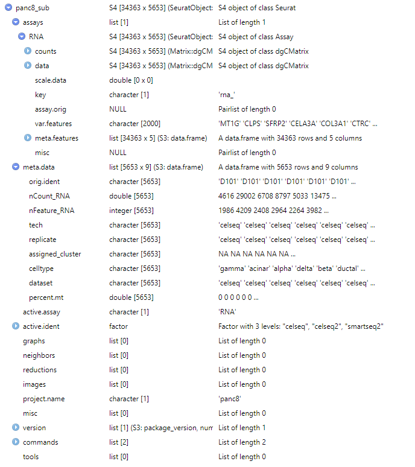

Notes (important slots):

- assays: contains different single-cell assay experimental data (ex: RNA, ATAC, etc.)
  - counts: raw counts
  - data: data worked on (this is be normalized throughout pipeline)
  - scale.data: scaled data
  - var.features: variable features (found through FindVariableFeatures)
- meta.data: metadata; can include categorical and numerical data
- active.assay: current assay slot used
- active.ident: current metadata/identity used
- graphs: contains KNN and SNN graphs (from FindNeighbors)
- reductions: contains PCA, TSNE, and UMAP data

# Adding and Replacing Metadata

```r
# Load in or get metadata
## Making up metadata here just for example

# Adding one description
merged$id <- Idents(merged) # store current identity
merged$mt1 <- rep(c(.5, .8), times = c(4500, 4500))

# Add directly if have metadata for each cell
## must have cell names as row names
metadata <- data.frame(group = rep(c(1, 2), times = c(4500,4500)), treat = rep(c('A', 'B', 'C'), times = c(2600, 1000, 5400)), row.names = colnames(merged))

merged <- AddMetaData(merged, metadata)

# Can replace metadata by using one of the ways above. For the table method, it will both add new metadata and replace any existing metadata. Need to make sure that you have the same number of cells for object and metadata table.
```

# Exploring Seurat Object

```r
# dimensions count table in object
## genes x cells
dim(merged)
head(colnames(merged))
head(rownames(merged))
ncol(merged)
nrow(merged)

# Changing identities
## Can be important for visualization and testing
Idents(merged) <- 'group'
Idents(merged, cells = 1:10) <- 'treat' # subset labels

# Checking current identity
levels(merged)

# Making metadata table
table(merged$treat)

# Rename label in current identity
Idents(merged) <- 'treat'
new_labels <- c('B' = 'A', 'C' = 'D')
merged <- RenameIdents(merged, new_labels)
```

# Manipulating Seurat Object

```r
# subsetting object
## based on logical expression
merged_sub <- subset(merged, subset = group == 1)
merged_sub <- subset(merged, subset = COL6A3 > 0)

## based on current identity
levels(merged)
merged_sub <- subset(merged, idents = c('A'))
# merged_sub <- subset(merged, idents = c('A'), invert = T) get everything except

# getting data
## can pull out genes and metadata for all cells
## ident = current identity
## will pull out from "data" slot by default
merged_data <- FetchData(merged, vars= c('COL6A', 'PPY', 'COL3A1', 'group', 'ident'))

# getting cells
## gives names of cells that matches expression or identity
merged_cells <- WhichCells(merged, idents = 'A')
#merged_cells <- WhichCells(merged, idents = 'A', invert = T)
merged_cells <- WhichCells(merged, expression = COL6A > 0)
```

# Exporting Seurat Object

```r
saveRDS(merged, file = 'scrnaseq_merged.rds')
```

# Standard Pipeline

```r
# install example data
# InstallData('panc8')
data('panc8')
panc8 <- UpdateSeuratObject(panc8) # need to update cause old version

table(panc8$dataset)

panc8_sub <- subset(panc8, idents = c('celseq', 'celseq2', 'smartseq2'))

#rm(panc8)
```

## Merge -> Pre-process -> Downstream Analysis

### QC

Notes:

- It is standard to look at nCount/nUMI, nFeature/nGene, and percentage of mitochondrial reads for each cell.
- nCount: total # of molecules detected within a cell
- nFeature: total # of genes detected in each cell.

Can also check percentage of ribosomal reads (I won’t be using this in this pipeline, but it is an option you can use):

```r
# human reads start with RPS or RPL
panc8_sub$percent.rb <- PercentageFeatureSet(panc8_sub, pattern = '^RP[SL]')
```

#### Before Filtering

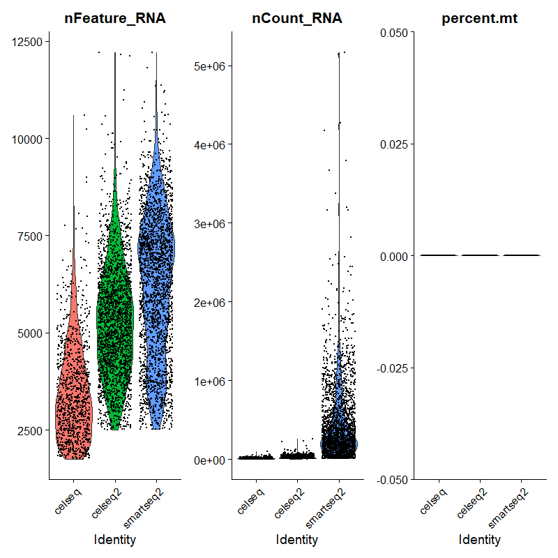

```r
# check percentage of mitochondrial reads
## human reads start with MT-
panc8_sub$percent.mt <- PercentageFeatureSet(panc8_sub, pattern = "^MT-")

VlnPlot(panc8_sub, features = c("nFeature_RNA", "nCount_RNA", "percent.mt"), ncol = 3, pt.size = .5)
```

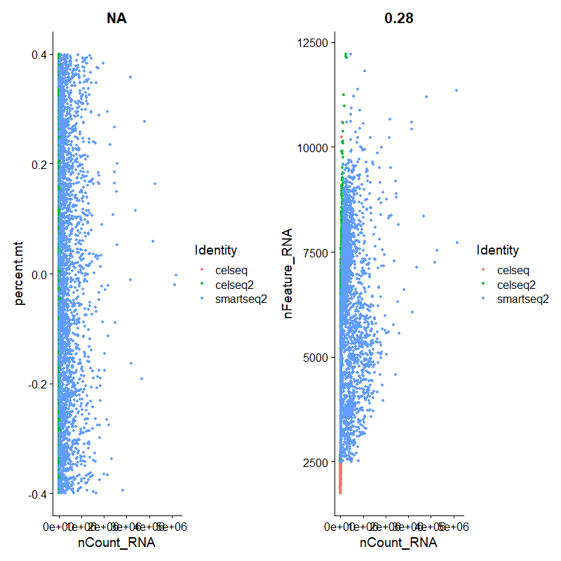

```r
plot1 <- FeatureScatter(object = panc8_sub, feature1 = "nCount_RNA", feature2 = "percent.mt")
plot2 <- FeatureScatter(object = panc8_sub, feature1 = "nCount_RNA", feature2 = "nFeature_RNA")
plot1 + plot2
```

#### After Filtering

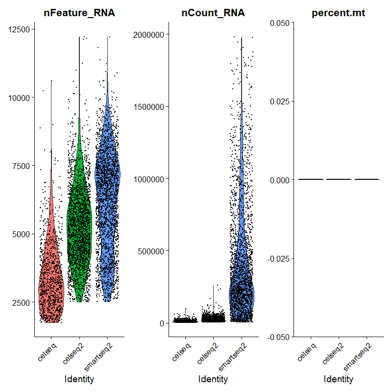

```r
panc8_sub <- subset(panc8_sub, subset = nCount_RNA < 2e6)

VlnPlot(panc8_sub, features = c("nFeature_RNA", "nCount_RNA", "percent.mt"), ncol = 3, pt.size = .5)
```

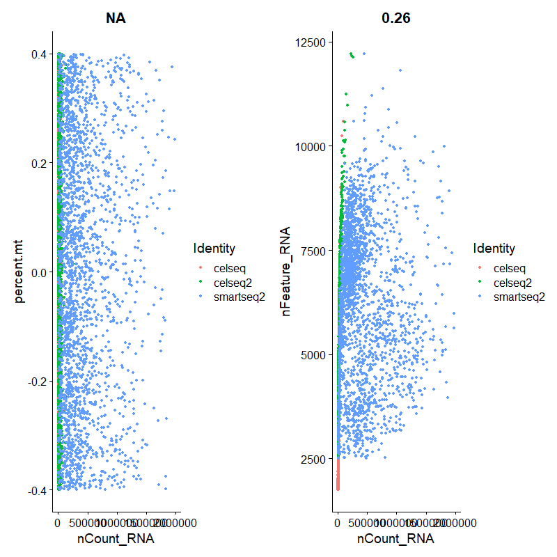

```r
plot1 <- FeatureScatter(object = panc8_sub, feature1 = "nCount_RNA", feature2 = "percent.mt")
plot2 <- FeatureScatter(object = panc8_sub, feature1 = "nCount_RNA", feature2 = "nFeature_RNA")
plot1 + plot2
```

Note:

- QC done here places a hard threshold where you set one threshold for all samples
- Can do a more lenient QC by setting a different threshold for each sample. You can see an example in “Pre-Process -> Merge -> Downstream” -> QC Section.

### Normalization

```r
panc8_sub <- NormalizeData(panc8_sub, normalization.method = 'LogNormalize', scale.factor = 10000)
# panc8 <- NormalizeData(panc8) is the same as above
```

### Finding Variable Features

#### VST

This is the current algorithm used to find variable features.

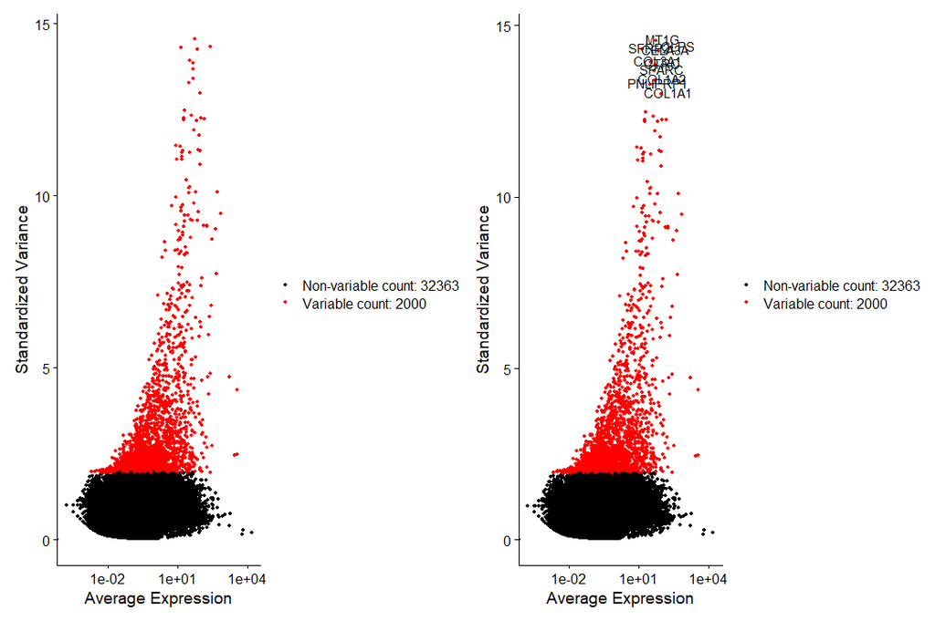

```r
## find subset of features that exhibit high cell-to-cell variation in the dataset
## vst --> loess.span, clip.max, nfeaturesmerge
panc8_sub <- FindVariableFeatures(panc8_sub, selection.method = 'vst', loess.span = .3, nfeatures = 2000)
### FindVariableFeatures(panc8_sub) is the same above

top10 <- head(VariableFeatures(panc8_sub), 10)
plot1 <- VariableFeaturePlot(panc8_sub)
plot2 <- LabelPoints(plot = plot1, points = top10)
plot1 + plot2
```

#### Mean Var

Old algorithm

```r
# ## mean.var.plot --> mean.function, dispersion.function, num.bin, mean/dispersion.cutoff
# panc8 <- FindVariableFeatures(panc8, selection.method = 'mean.var.plot', mean.cutoff = c(0.0125,Inf), dispersion.cutoff = c(0.5,Inf))
#
# top10 <- head(VariableFeatures(panc8), 10)
# plot1 <- VariableFeaturePlot(panc8)
# plot2 <- LabelPoints(plot = plot1, points = top10)
# plot1 + plot2
```

### Scaling

```r
# OPTION 1 (all genes):
## can take a long time to run
panc8_sub <- ScaleData(panc8_sub, features = rownames(panc8_sub), vars.to.regress = c('nCount_RNA'))

# OPTION 2 (variable genes):
## default features parameter is variable genes
# panc8_sub <- ScaleData(panc8_sub, vars.to.regress = 'nCount_RNA')
```

### PCA

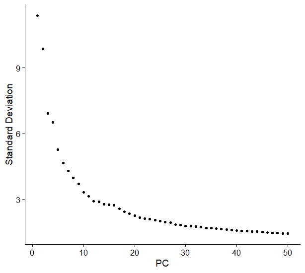

```r
# DIMENSIONAL REDUCTION: PCA
## Can control the number of pcs that you want to calculate w/ npcs
panc8_sub <- RunPCA(object = panc8_sub, features = VariableFeatures(object = panc8_sub),
                nfeatures.print = 5)

# Choosing how many PCs for clustering
# visualizing pcs
ElbowPlot(object = panc8_sub, ndims = 50)

# JackStraw if you want
panc8_sub <- JackStraw(object = panc8_sub, num.replicate = 100)
panc8_sub <- ScoreJackStraw(object = panc8_sub, dims = 1:20)
JackStrawPlot(object = panc8_sub, dims = 1:20)

# # Calculating --> until get over 90% variance
# ## old way
# stdev <- panc8_sub[['pca']]@stdev
# var <- (panc8_sub[['pca']]@stdev)^2
# sum(var[1:28])/sum(var)

# Quantitative approach
## point where pcs only contribute 5% of stdev and cumulatively contribute 90% of stdev
pct <- panc8_sub@reductions$pca@stdev / sum(panc8_sub@reductions$pca@stdev) * 100 # % variation associated w/ each pc
cum <- cumsum(pct) # cumulative % for each pc
co1 <- which(cum > 90 & pct < 5)[1] # upper threshold

## point where percent change in variation b/w consecutive pcs is < 0.1%
co2 <- sort(which((pct[1:length(pct)-1] - pct[2:length(pct)]) > .1), decreasing = T)[1] + 1 # difference b/w variation of pc and subsequent pc
# lower threshold

### use minimum of 2 metrics
pcs <- min(co1, co2)
```

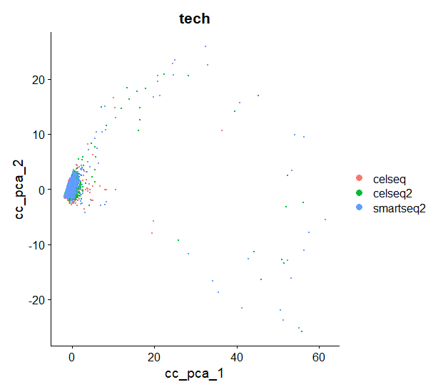

```r
# Check for any batch effects (mainly cell cycle batch)
# Cell cycle genes (if want to do cell cycle correction) (human)
## mouse is somewhere else but I have downloaded it
s_genes <- cc.genes.updated.2019$s.genes
g2m_genes <- cc.genes.updated.2019$g2m.genes

# if have old gene names can use this function to change
cc.genes.updated.2019$s.genes <- UpdateSymbolList(cc.genes.updated.2019$s.genes)
cc.genes.updated.2019$g2m.genes <- UpdateSymbolList(cc.genes.updated.2019$g2m.genes)

panc8_sub <- RunPCA(object = panc8_sub, features = c(s_genes, g2m_genes),
                nfeatures.print = 5, reduction.name = 'cc_pca')
DimPlot(panc8_sub, reduction = 'cc_pca', group.by = 'tech')
### don't need to do cell cycle correction with this example
```

#### Cell Cycle Correction

```r
# use if want all cell cycle signals regressed out
panc8_sub <- CellCycleScoring(object = panc8_sub, s.features = s_genes, g2m.features = g2m_genes, set.ident = TRUE)
panc8_sub <- ScaleData(object = panc8_sub, features = all.genes,
                   vars.to.regress = c("nCount", 'S.Score', 'G2M.Score'))
### use if want some cell cycle signals regressed out (cycling vs. non-cycling will be save)
### mainly used if looking at differentiating processes
panc8_sub$CC.Difference <- panc8_sub$S.Score - panc8_sub$G2M.Score
panc8_sub <- ScaleData(object = panc8_sub, features = all.genes,
                   vars.to.regress = c("nCount", "CC.Difference"))

# Run PCA again with cell cycle regressed data
panc8_sub <- RunPCA(object = panc8_sub, features = VariableFeatures(object = panc8_sub),
                nfeatures.print = 5)
```

### Batch Correction w/ Harmony

```r
# BATCH CORRECTION
## if know that you have batch effect from either previous info or from running through clustering and visualization
## using harmony package
panc8_sub <- RunHarmony(panc8_sub, group.by.vars = c('tech'), dims.use = 1:pcs, verbose = F)
```

### Not Batch Corrected

#### Clustering

```r
panc8_sub <- FindNeighbors(panc8_sub, dims = 1:pcs, k.param = 20)
panc8_sub <- FindClusters(panc8_sub, resolution = 0.5)
head(Idents(panc8_sub), 5)
# store clusters in other metadata slot
panc8_sub$ex_unbatch_clusters <- Idents(panc8_sub)

# cluster will be stored in seurat_clusters and every time you run FindClusters it will overwrite seurat_clusters metadata
```

#### TSNE/UMAP

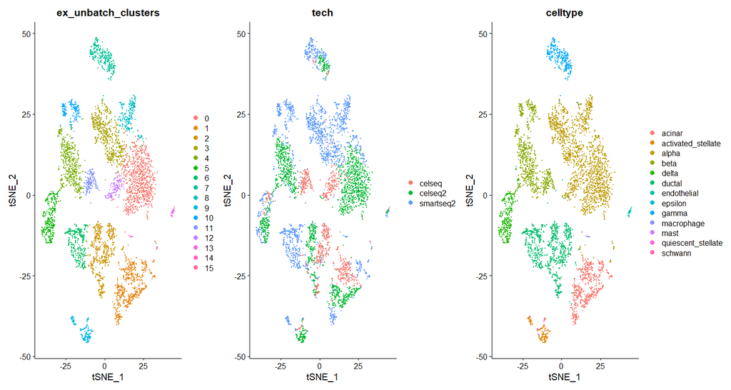

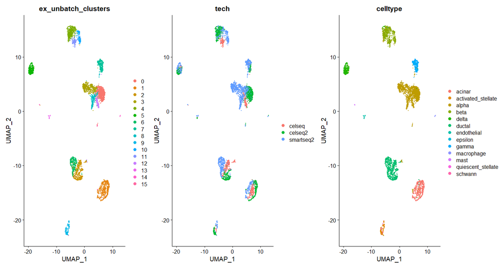

```r
# VISUALIZATION: TSNE/UMAP
## TSNE example
panc8_sub <- RunTSNE(panc8_sub, dims = 1:pcs, reduction.name = 'tsne_unbatch')
DimPlot(object = panc8_sub, reduction = 'tsne_unbatch', group.by = c('ex_unbatch_clusters','tech','celltype'))

## UMAP example
panc8_sub <- RunUMAP(panc8_sub, dims = 1:pcs, reduction.name = 'umap_unbatch')
DimPlot(object = panc8_sub, reduction = 'umap_unbatch', group.by = c('ex_unbatch_clusters','tech','celltype'))
### if want to use current identity, use 'ident' in group.by
```

### Batch Corrected

#### Clustering

```r
panc8_sub <- FindNeighbors(panc8_sub, dims = 1:pcs, k.param = 20, reduction = 'harmony')
panc8_sub <- FindClusters(panc8_sub, resolution = 0.5)
head(Idents(panc8_sub), 5)
# store clusters in other metadata slot
panc8_sub$ex_batch_clusters <- Idents(panc8_sub)
```

#### TSNE/UMAP

```r
### if batch corrected:
panc8_sub <- RunTSNE(panc8_sub, dims = 1:pcs, reduction = 'harmony', reduction.name = 'batch_tsne')
DimPlot(object = panc8_sub, reduction = 'batch_tsne', group.by = c('ex_batch_clusters','tech','celltype'))

panc8_sub <- RunUMAP(panc8_sub, dims = 1:pcs, reduction = 'harmony', reduction.name = 'batch_umap')
DimPlot(object = panc8_sub, reduction = 'batch_umap', group.by = c('ex_batch_clusters','tech','celltype'))
```

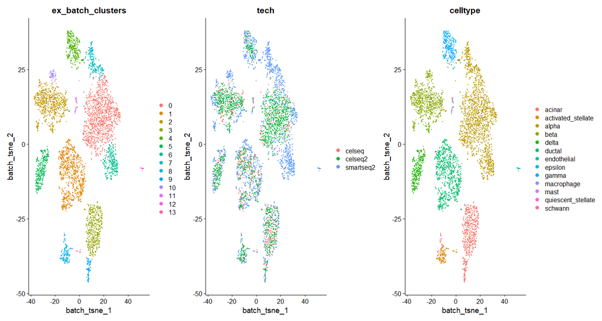

```r
knitr::include_graphics("example_datasets/figures/merge_process_figures/tsne_batch.png")
```

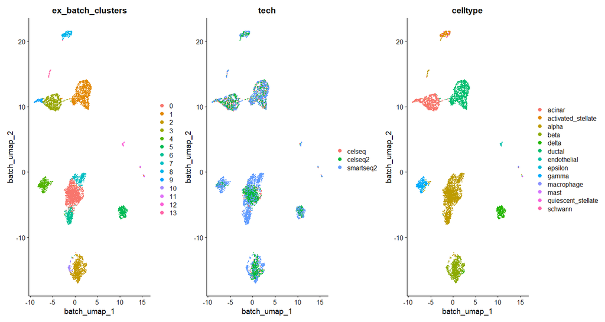

```r
knitr::include_graphics("example_datasets/figures/merge_process_figures/umap_batch.png")
```

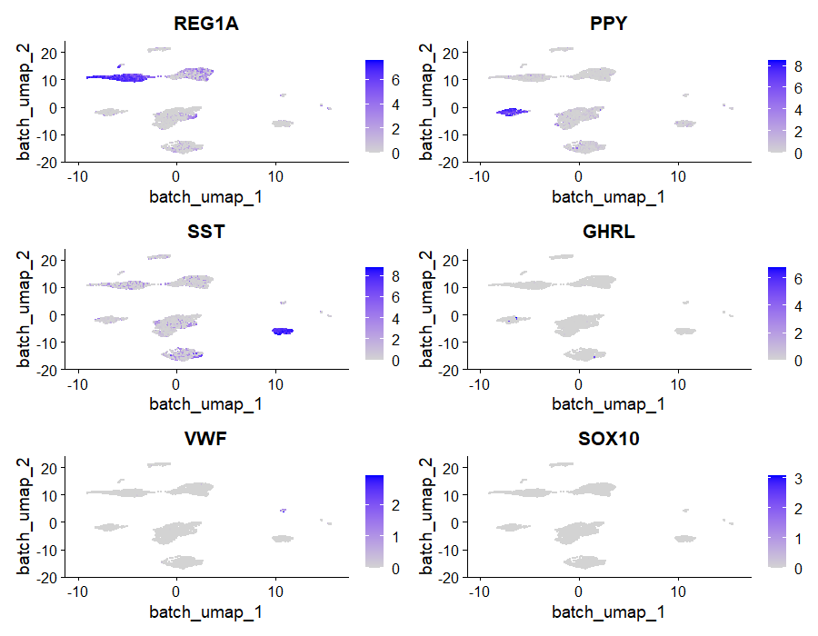

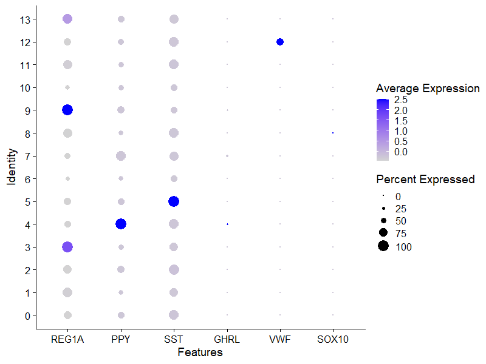

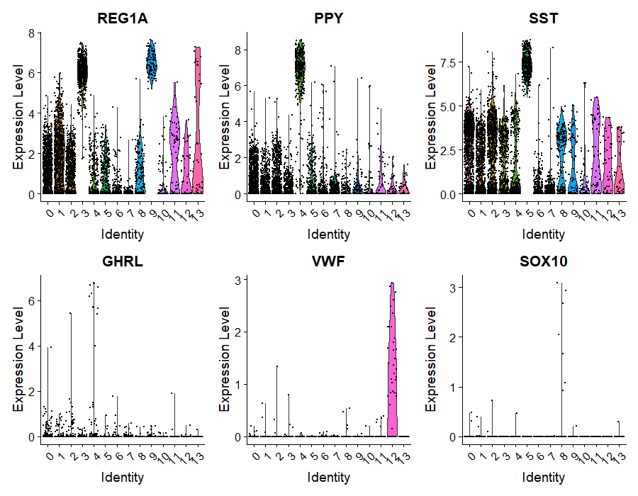

```r
## Visualizing expression
### can use these parameters to change plots: features, idents, split.by, group.by
FeaturePlot(panc8_sub, reduction = 'batch_umap', features = c('REG1A', 'PPY', 'SST', 'GHRL', 'VWF', 'SOX10'))
DotPlot(panc8_sub, features = c('REG1A', 'PPY', 'SST', 'GHRL', 'VWF', 'SOX10'))
VlnPlot(panc8_sub, features = c('REG1A', 'PPY', 'SST', 'GHRL', 'VWF', 'SOX10'))
```

### DE

```r
# DIFFERENTIAL EXPRESSION
## markers for cluster 0 (will compare cluster 1 to all other clusters)
cluster1_markers <- FindMarkers(object = panc8_sub, ident.1 = 0, min.pct = 0.25)
head(x = cluster1_markers, n = 5)

## markers for all clusters
panc8_sub_markers <- FindAllMarkers(object = panc8_sub, only.pos = TRUE, min.pct = 0.25,
                                logfc.threshold = 0.25)
panc8_sub_markers %>% group_by(cluster) %>% top_n(n = 2, wt = avg_log2FC)
```

### Conserved Features

Useful in finding conserved features among all conditions in dataset (ex: test and control). It can help if have any unknown clusters.

```r
# one cluster
panc8_sub_conserved_markers <- FindConservedMarkers(panc8_sub, ident.1 = 0, grouping.var = 'tech', only.pos = T)

# multiple clusters
get_conserved <- function(cluster) {
  FindConservedMarkers(panc8_sub, ident.1 = cluster, grouping.var = 'tech', only.pos = T) %>% rownames_to_column(var = 'gene') %>% cbind(cluster_id = cluster, .)
}

panc8_sub_conserved_markers <- map_dfr(c(0,1), get_conserved)
```

## Pre-Process -> Merge -> Downstream

```r
# install example data
# InstallData('panc8')
data('panc8')
panc8 <- UpdateSeuratObject(panc8) # need to update cause old version

table(panc8$dataset)

panc8_sub <- SplitObject(panc8, split.by = 'dataset')
panc8_sub <- panc8_sub[c('celseq', 'celseq2', 'smartseq2')]

#rm(panc8)
```

### QC

#### Before filtering

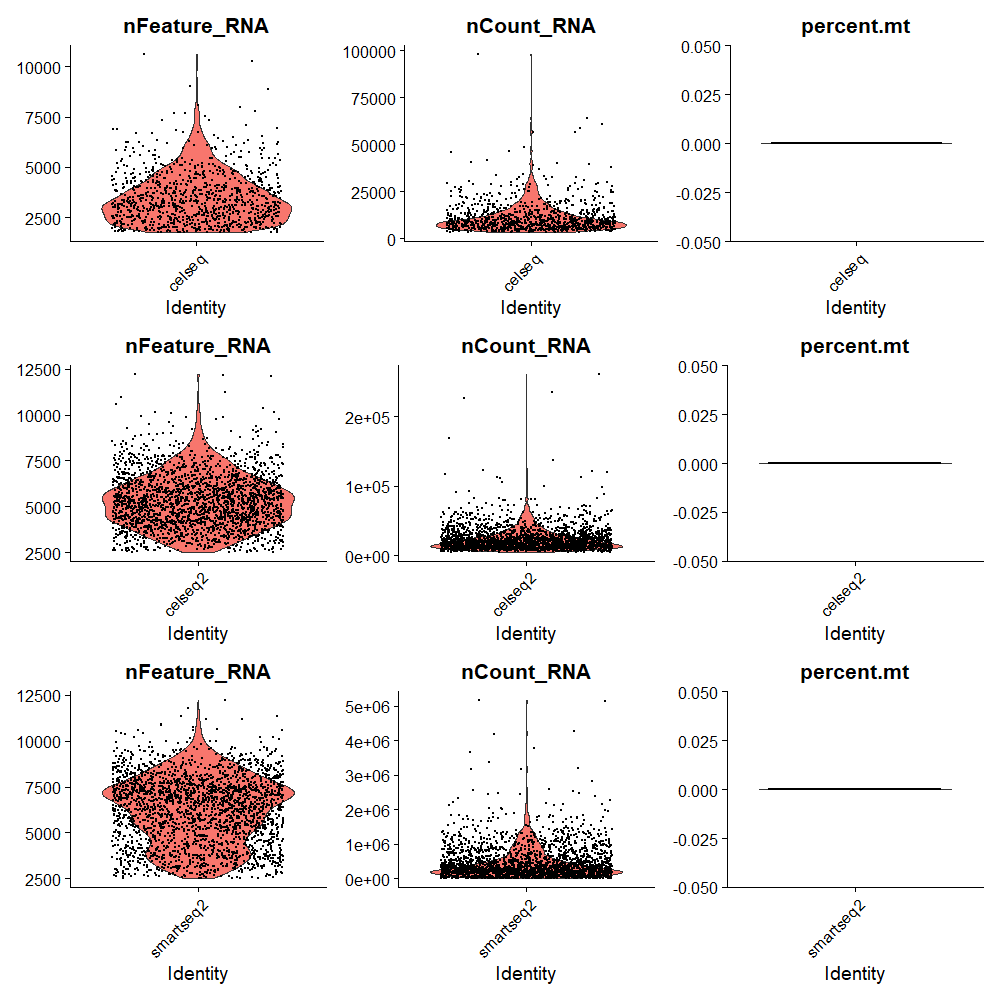

```r
for (i in 1:length(panc8_sub)) {
  panc8_sub[[i]][['percent.mt']] <- PercentageFeatureSet(panc8_sub[[i]], pattern = "^MT-")
}

plot_list <- list()
for (i in 1:length(panc8_sub)) {
  plot_list[[i]] <- VlnPlot(panc8_sub[[i]], features = c("nFeature_RNA", "nCount_RNA", "percent.mt"), ncol = 3, pt.size = .5)
}

plot_list[[1]] / plot_list[[2]] / plot_list[[3]]
```

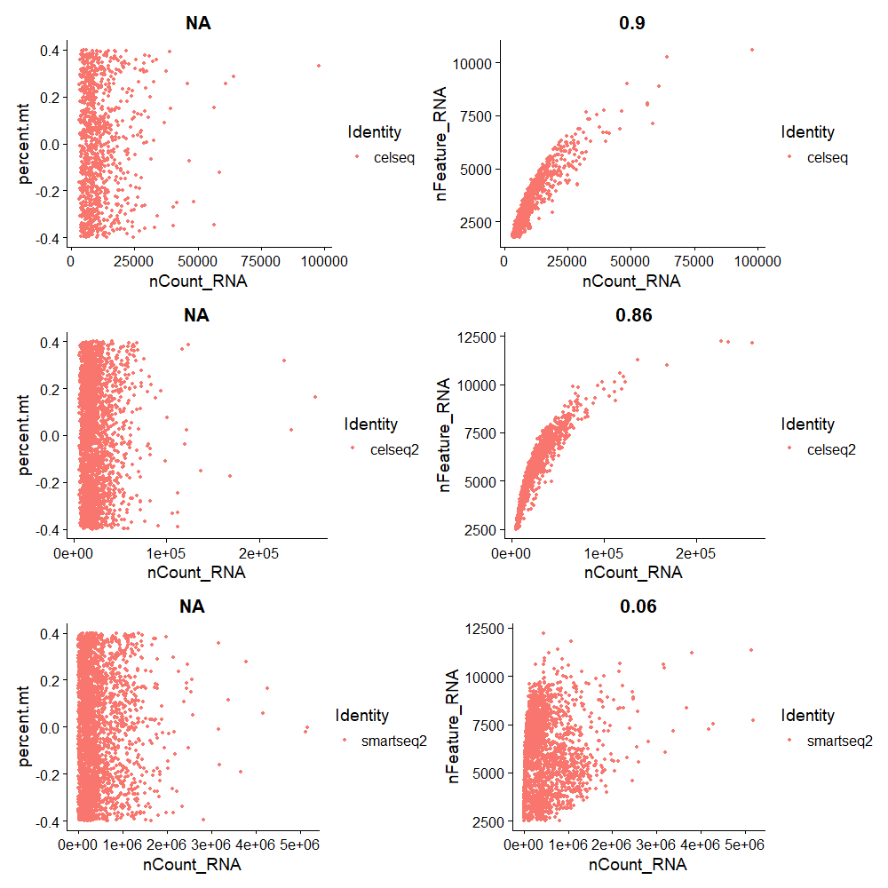

```r
plot_list <- list()
for (i in 1:length(panc8_sub)) {
  plot_list[[i]] <- FeatureScatter(object = panc8_sub[[i]], feature1 = "nCount_RNA", feature2 = "percent.mt") + FeatureScatter(object = panc8_sub[[i]], feature1 = "nCount_RNA", feature2 = "nFeature_RNA")
}

plot_list[[1]] / plot_list[[2]] / plot_list[[3]]
```

#### After filtering

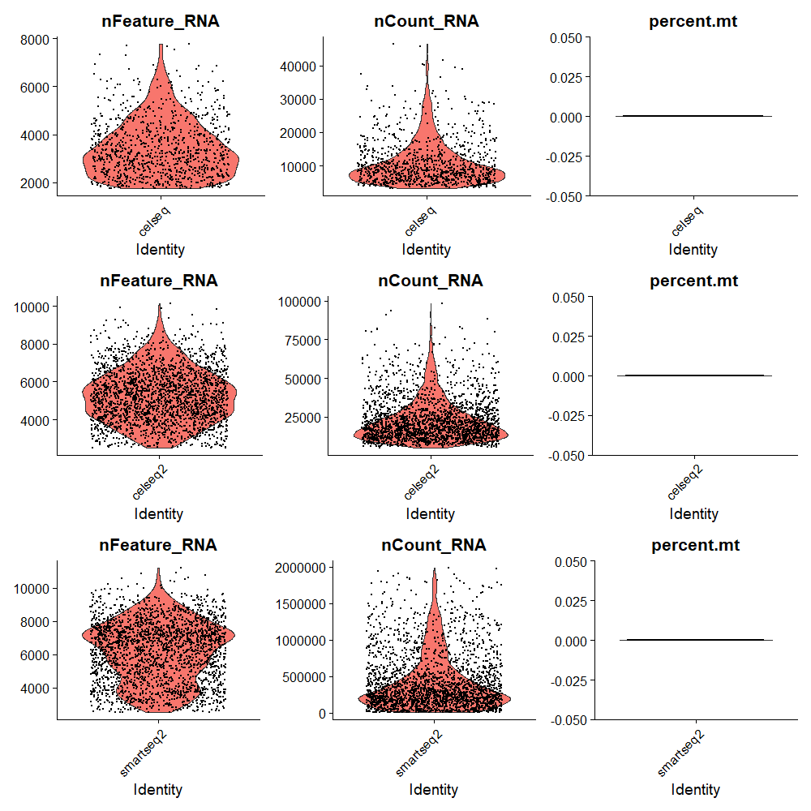

```r
panc8_sub[[1]] <- subset(panc8_sub[[1]], subset = nFeature_RNA < 8500 & nCount_RNA < 50000)
panc8_sub[[2]] <- subset(panc8_sub[[2]], subset = nFeature_RNA < 11000 & nCount_RNA < 1e5)
panc8_sub[[3]] <- subset(panc8_sub[[3]], subset = nFeature_RNA < 11250 & nCount_RNA < 2e6)

plot_list <- list()
for (i in 1:length(panc8_sub)) {
  plot_list[[i]] <- VlnPlot(panc8_sub[[i]], features = c("nFeature_RNA", "nCount_RNA", "percent.mt"), ncol = 3, pt.size = .5)
}

plot_list[[1]] / plot_list[[2]] / plot_list[[3]]
```

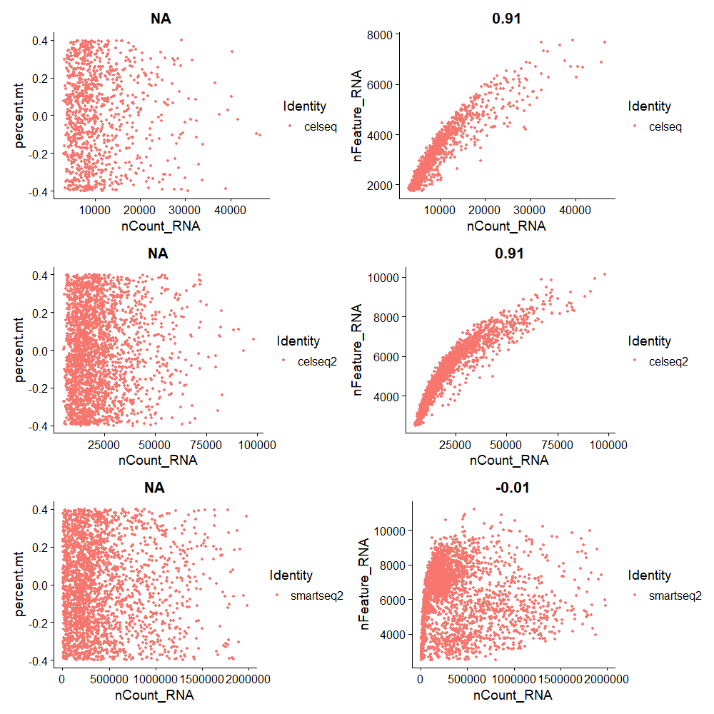

```r
plot_list <- list()
for (i in 1:length(panc8_sub)) {
  plot_list[[i]] <- FeatureScatter(object = panc8_sub[[i]], feature1 = "nCount_RNA", feature2 = "percent.mt") + FeatureScatter(object = panc8_sub[[i]], feature1 = "nCount_RNA", feature2 = "nFeature_RNA")
}

plot_list[[1]] / plot_list[[2]] / plot_list[[3]]
```

### Merge –> Harmony

#### Merge objects

```r
# Merge objects together
panc8_sub_merge <- merge(panc8_sub[[1]], c(panc8_sub[[2]], panc8_sub[[3]]))
```

#### Normalization

```r
panc8_sub_merge <- NormalizeData(panc8_sub_merge)
```

#### Finding Variable Features

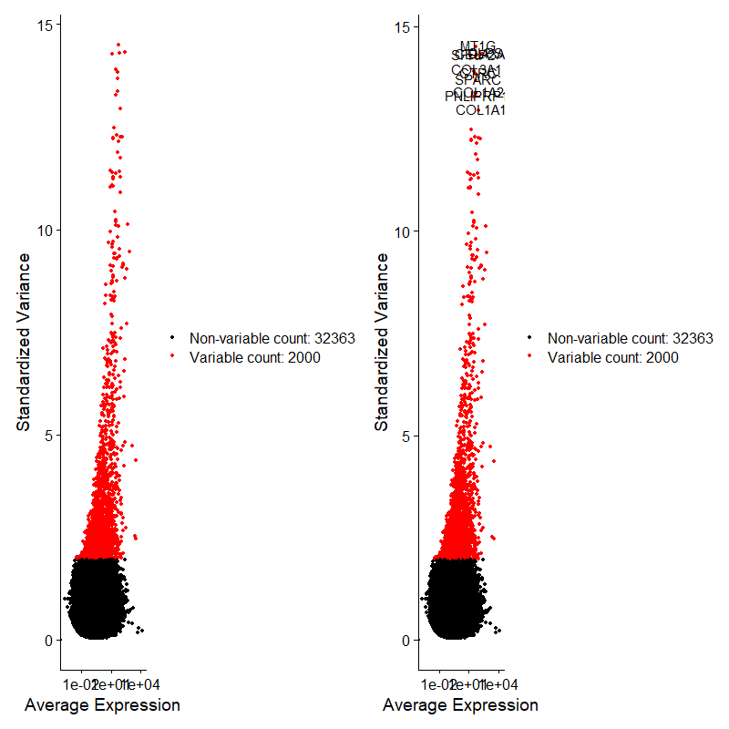

```r
## find subset of features that exhibit high cell-to-cell variation in the dataset
## vst --> loess.span, clip.max, nfeaturesmerge
panc8_sub_merge <- FindVariableFeatures(panc8_sub_merge, selection.method = 'vst', loess.span = .3, nfeatures = 2000)

top10 <- head(VariableFeatures(panc8_sub_merge), 10)
plot1 <- VariableFeaturePlot(panc8_sub_merge)
plot2 <- LabelPoints(plot = plot1, points = top10)
plot1 + plot2
```

#### Scaling

```r
# OPTION 1 (all genes):
panc8_sub_merge <- ScaleData(panc8_sub_merge, features = rownames(panc8_sub_merge), vars.to.regress = c('nCount_RNA'))
```

#### PCA

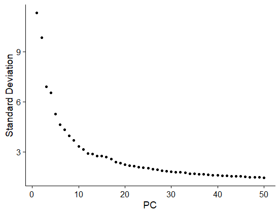

```r
# DIMENSIONAL REDUCTION: PCA
## Can control the number of pcs that you want to calculate w/ npcs
panc8_sub_merge <- RunPCA(object = panc8_sub_merge, features = VariableFeatures(object = panc8_sub_merge),
                nfeatures.print = 5)

# Choosing how many PCs for clustering
# visualizing pcs
ElbowPlot(object = panc8_sub_merge, ndims = 50)

# JackStraw if you want
panc8_sub_merge <- JackStraw(object = panc8_sub_merge, num.replicate = 100)
panc8_sub_merge <- ScoreJackStraw(object = panc8_sub_merge, dims = 1:20)
JackStrawPlot(object = panc8_sub_merge, dims = 1:20)

# # Calculating --> until get over 90% variance
# stdev <- panc8_sub_merge[['pca']]@stdev
# var <- (panc8_sub_merge[['pca']]@stdev)^2
# sum(var[1:28])/sum(var)

# Quantitative approach
## point where pcs only contribute 5% of stdev and cumulatively contribute 90% of stdev
pct <- panc8_sub_merge@reductions$pca@stdev / sum(panc8_sub_merge@reductions$pca@stdev) * 100 # % variation associated w/ each pc
cum <- cumsum(pct) # cumulative % for each pc
co1 <- which(cum > 90 & pct < 5)[1] # upper threshold

## point where percent change in variation b/w consecutive pcs is < 0.1%
co2 <- sort(which((pct[1:length(pct)-1] - pct[2:length(pct)]) > .1), decreasing = T)[1] + 1 # difference b/w variation of pc and subsequent pc
# lower threshold

### use minimum of 2 metrics
pcs <- min(co1, co2)
```

```r
# Check for any batch effects (mainly cell cycle batch)
# Cell cycle genes (if want to do cell cycle correction) (human)
## mouse is somewhere else but I have downloaded it
s_genes <- cc.genes.updated.2019$s.genes
g2m_genes <- cc.genes.updated.2019$g2m.genes

# if have old gene names can use this function to change
cc.genes.updated.2019$s.genes <- UpdateSymbolList(cc.genes.updated.2019$s.genes)
cc.genes.updated.2019$g2m.genes <- UpdateSymbolList(cc.genes.updated.2019$g2m.genes)

panc8_sub_merge <- RunPCA(object = panc8_sub_merge, features = c(s_genes, g2m_genes),
                nfeatures.print = 5, reduction.name = 'cc_pca')
DimPlot(panc8_sub_merge, reduction = 'cc_pca', group.by = 'tech')
### don't need to do cell cycle correction with this example
```

##### Cell Cycle Correction

```r
# use if want all cell cycle signals regressed out
# panc8_sub_merge <- CellCycleScoring(object = panc8_sub_merge, s.features = s_genes, g2m.features = g2m_genes, set.ident = TRUE)
# panc8_sub_merge <- ScaleData(object = panc8_sub_merge, features = all.genes,
#                    vars.to.regress = c("nCount", 'S.Score', 'G2M.Score'))
# ### use if want some cell cycle signals regressed out (cycling vs. non-cycling will be save)
# ### mainly used if looking at differentiating processes
# panc8_sub_merge$CC.Difference <- panc8_sub_merge$S.Score - panc8_sub_merge$G2M.Score
# panc8_sub_merge <- ScaleData(object = panc8_sub_merge, features = all.genes,
#                    vars.to.regress = c("nCount", "CC.Difference"))

# # Run PCA again with cell cycle regressed data
# panc8_sub_merge <- RunPCA(object = panc8_sub_merge, features = VariableFeatures(object = panc8_sub_merge),
#                 nfeatures.print = 5)
```

#### Batch Correction w/ Harmony

```r
# BATCH CORRECTION
## if know that you have batch effect from either previous info or from running through clustering and visualization
## using harmony package
panc8_sub_merge <- RunHarmony(panc8_sub_merge, group.by.vars = c('tech'), dims.use = 1:pcs, verbose = F)
```

#### Not Batch Corrected

##### Clustering

```r
panc8_sub_merge <- FindNeighbors(panc8_sub_merge, dims = 1:pcs, k.param = 20)
panc8_sub_merge <- FindClusters(panc8_sub_merge, resolution = 0.5)
head(Idents(panc8_sub_merge), 5)
# store clusters in other metadata slot
panc8_sub_merge$ex_unbatch_clusters <- Idents(panc8_sub_merge)

# cluster will be stored in seurat_clusters and every time you run FindClusters it will overwrite seurat_clusters metadata
```

##### TSNE/UMAP

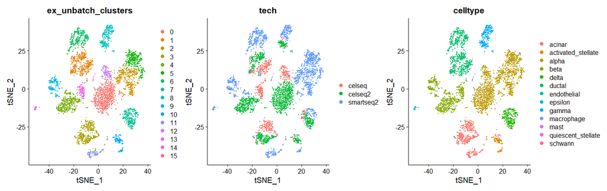

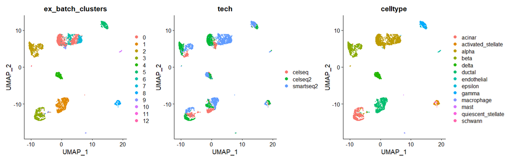

```r
# VISUALIZATION: TSNE/UMAP
## TSNE example
panc8_sub_merge <- RunTSNE(panc8_sub_merge, dims = 1:pcs, reduction.name = 'tsne_unbatch')
DimPlot(object = panc8_sub_merge, reduction = 'tsne_unbatch', group.by = c('ex_unbatch_clusters','tech','celltype'))

## UMAP example
panc8_sub_merge <- RunUMAP(panc8_sub_merge, dims = 1:pcs, reduction.name = 'umap_unbatch')
DimPlot(object = panc8_sub_merge, reduction = 'umap_unbatch', group.by = c('ex_batch_clusters','tech','celltype'))
### if want to use current identity, use 'ident' in group.by
```

#### Batch Corrected

##### Clustering

```r
panc8_sub_merge <- FindNeighbors(panc8_sub_merge, dims = 1:pcs, k.param = 20, reduction = 'harmony')
panc8_sub_merge <- FindClusters(panc8_sub_merge, resolution = 0.5)
head(Idents(panc8_sub_merge), 5)
# store clusters in other metadata slot
panc8_sub_merge$ex_batch_clusters <- Idents(panc8_sub_merge)
```

##### TSNE/UMAP

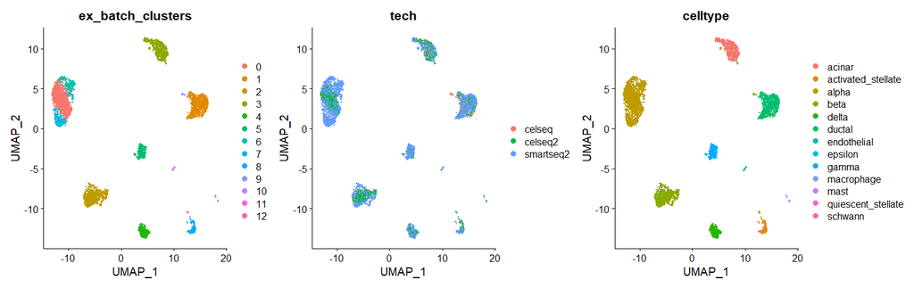

```r
### if batch corrected:
panc8_sub_merge <- RunTSNE(panc8_sub_merge, dims = 1:pcs, reduction = 'harmony', reduction.name = 'batch_tsne')
DimPlot(object = panc8_sub_merge, reduction = 'batch_tsne', group.by = c('ex_batch_clusters','tech','celltype'))

panc8_sub_merge <- RunUMAP(panc8_sub_merge, dims = 1:pcs, reduction = 'harmony', reduction.name = 'batch_umap')
DimPlot(object = panc8_sub_merge, reduction = 'batch_umap', group.by = c('ex_batch_clusters','tech','celltype'))
```

[output not shown]

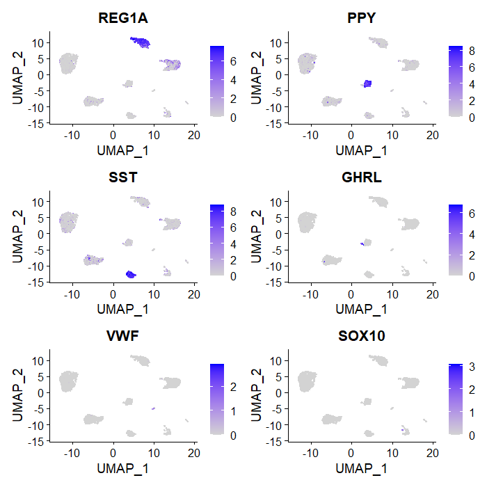

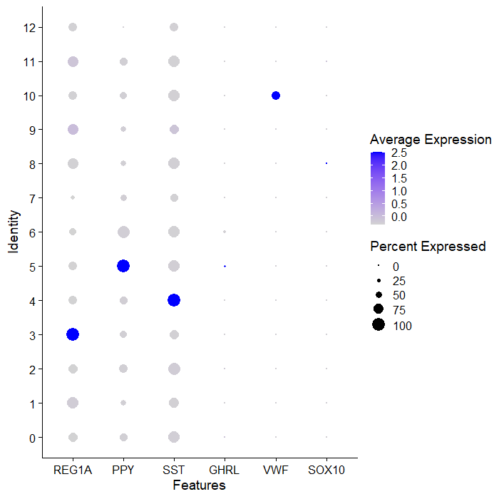

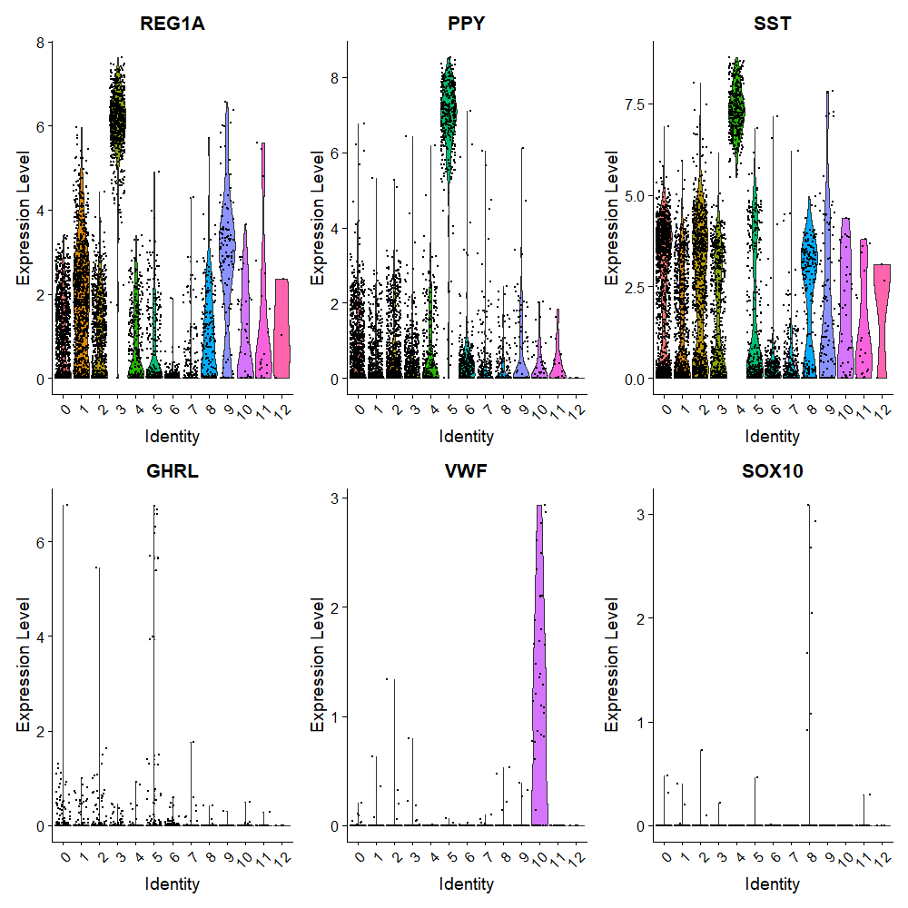

```r
## Visualizing expression
### can use these parameters to change plots: features, idents, split.by, group.by
FeaturePlot(panc8_sub_merge, reduction = 'batch_umap', features = c('REG1A', 'PPY', 'SST', 'GHRL', 'VWF', 'SOX10'))
DotPlot(panc8_sub_merge, features = c('REG1A', 'PPY', 'SST', 'GHRL', 'VWF', 'SOX10'))
VlnPlot(panc8_sub_merge, features = c('REG1A', 'PPY', 'SST', 'GHRL', 'VWF', 'SOX10'))
```

#### DE

```r
# DIFFERENTIAL EXPRESSION
## markers for cluster 0 (will compare cluster 1 to all other clusters)
cluster1_markers <- FindMarkers(object = panc8_sub_merge, ident.1 = 0, min.pct = 0.25)
head(x = cluster1_markers, n = 5)

## markers for all clusters
panc8_sub_merge_markers <- FindAllMarkers(object = panc8_sub_merge, only.pos = TRUE, min.pct = 0.25,
                                logfc.threshold = 0.25)
panc8_sub_merge_markers %>% group_by(cluster) %>% top_n(n = 2, wt = avg_log2FC)
```

#### Conserved Features

Useful in finding conserved features among all conditions in dataset (ex: test and control). It can help if have any unknown clusters.

```r
# one cluster
panc8_sub_merge_conserved_markers <- FindConservedMarkers(panc8_sub_merge, ident.1 = 0, grouping.var = 'tech', only.pos = T)

# multiple clusters
get_conserved <- function(cluster) {
  FindConservedMarkers(panc8_sub_merge, ident.1 = cluster, grouping.var = 'tech', only.pos = T) %>% rownames_to_column(var = 'gene') %>% cbind(cluster_id = cluster, .)
}

panc8_sub_merge_conserved_markers <- map_dfr(c(0,1), get_conserved)
```

### Further Pre-processing -> Integrate

#### Normalization & Variable Features

```r
## vst --> loess.span, clip.max, nfeaturesmerge
for (i in 1:length(panc8_sub)) {
  panc8_sub[[i]] <- NormalizeData(panc8_sub[[i]], verbose = F)
  panc8_sub[[i]] <- FindVariableFeatures(panc8_sub[[i]], selection.method = 'vst', nfeatures = 2000, verbose = F)
}
```

```r
# ## mean.var.plot --> mean.function, dispersion.function, num.bin, mean/dispersion.cutoff
# for (i in 1:length(panc8_sub)) {
#   panc8_sub[[i]] <- NormalizeData(panc8_sub[[i]], verbose = F)
#   panc8_sub[[i]] <- FindVariableFeatures(panc8_sub[[i]], selection.method = 'mean.var.plot', mean.cutoff = c(0.0125,Inf), dispersion.cutoff = c(0.5,Inf))
# }
```

##### Variable Features Plots

[figure not shown]

```r
top10_list <- sapply(1:length(panc8_sub), function(i) { head(VariableFeatures(panc8_sub[[i]]), 10)})

plot_list <- list()
for (i in 1:length(panc8_sub)) {
  p1 <- VariableFeaturePlot(panc8_sub[[i]])
  p2 <- LabelPoints(plot = p1, points = top10_list[,1])
  plot_list[[i]] <- p1+p2
}

plot_list[[1]] + plot_list[[2]] + plot_list[[3]]
```

#### Integration

```r
## identify anchors
panc8_sub_anchors <- FindIntegrationAnchors(object.list = panc8_sub, dims = 1:30)
## integrate objects
panc8_sub_integrate <- IntegrateData(anchorset = panc8_sub_anchors, dims = 1:30)

## change assay to integrated slot
DefaultAssay(panc8_sub_integrate) <- 'integrated'
```

#### Scaling

```r
# OPTION 1 (all genes):
panc8_sub_integrate <- ScaleData(panc8_sub_integrate, features = rownames(panc8_sub_integrate), vars.to.regress = c('nCount_RNA'))
```

#### PCA

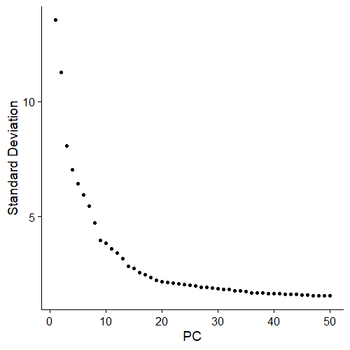

```r
# DIMENSIONAL REDUCTION: PCA
## Can control the number of pcs that you want to calculate w/ npcs
panc8_sub_integrate <- RunPCA(object = panc8_sub_integrate, features = VariableFeatures(object = panc8_sub_integrate),
                nfeatures.print = 5)

# Choosing how many PCs for clustering
# visualizing pcs
ElbowPlot(object = panc8_sub_integrate, ndims = 50)

# JackStraw if you want
panc8_sub_integrate <- JackStraw(object = panc8_sub_integrate, num.replicate = 100)
panc8_sub_integrate <- ScoreJackStraw(object = panc8_sub_integrate, dims = 1:20)
JackStrawPlot(object = panc8_sub_integrate, dims = 1:20)

# # Calculating --> until get over 90% variance
# ## old way
# stdev <- panc8_sub[['pca']]@stdev
# var <- (panc8_sub[['pca']]@stdev)^2
# sum(var[1:28])/sum(var)

# Quantitative approach
## point where pcs only contribute 5% of stdev and cumulatively contribute 90% of stdev
pct <- panc8_sub_integrate@reductions$pca@stdev / sum(panc8_sub_integrate@reductions$pca@stdev) * 100 # % variation associated w/ each pc
cum <- cumsum(pct) # cumulative % for each pc
co1 <- which(cum > 90 & pct < 5)[1] # upper threshold

## point where percent change in variation b/w consecutive pcs is < 0.1%
co2 <- sort(which((pct[1:length(pct)-1] - pct[2:length(pct)]) > .1), decreasing = T)[1] + 1 # difference b/w variation of pc and subsequent pc
# lower threshold

### use minimum of 2 metrics
pcs <- min(co1, co2)
```

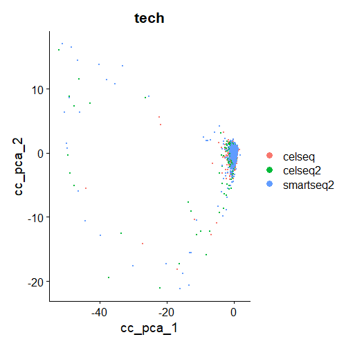

```r
# Check for any batch effects (mainly cell cycle batch)
# Cell cycle genes (if want to do cell cycle correction) (human)
## mouse is somewhere else but I have downloaded it
s_genes <- cc.genes.updated.2019$s.genes
g2m_genes <- cc.genes.updated.2019$g2m.genes

# if have old gene names can use this function to change
cc.genes.updated.2019$s.genes <- UpdateSymbolList(cc.genes.updated.2019$s.genes)
cc.genes.updated.2019$g2m.genes <- UpdateSymbolList(cc.genes.updated.2019$g2m.genes)

panc8_sub_integrate <- RunPCA(object = panc8_sub_integrate, features = c(s_genes, g2m_genes),
                nfeatures.print = 5, reduction.name = 'cc_pca')
DimPlot(panc8_sub_integrate, reduction = 'cc_pca', group.by = 'tech')
### don't need to do cell cycle correction with this example
```

##### Cell Cycle Correction

```r
# # use if want all cell cycle signals regressed out
# panc8_sub_integrate <- CellCycleScoring(object = panc8_sub_integrate, s.features = s_genes, g2m.features = g2m_genes, set.ident = TRUE)
# panc8_sub_integrate <- ScaleData(object = panc8_sub_integrate, features = all.genes,
#                    vars.to.regress = c("nCount", 'S.Score', 'G2M.Score'))
# ### use if want some cell cycle signals regressed out (cycling vs. non-cycling will be save)
# ### mainly used if looking at differentiating processes
# panc8_sub_integrate$CC.Difference <- panc8_sub_integrate$S.Score - panc8_sub_integrate$G2M.Score
# panc8_sub_integrate <- ScaleData(object = panc8_sub_integrate, features = all.genes,
#                    vars.to.regress = c("nCount", "CC.Difference"))
#
# # Run PCA again with cell cycle regressed data
# panc8_sub_integrate <- RunPCA(object = panc8_sub_integrate, features = VariableFeatures(object = panc8_sub_integrate),
#                 nfeatures.print = 5)
```

#### Clustering

```r
panc8_sub_integrate <- FindNeighbors(panc8_sub_integrate, dims = 1:pcs, k.param = 20)
panc8_sub_integrate <- FindClusters(panc8_sub_integrate, resolution = 0.5)
head(Idents(panc8_sub_integrate), 5)
# store clusters in other metadata slot
panc8_sub_integrate$ex_integrate_clusters <- Idents(panc8_sub_integrate)

# cluster will be stored in seurat_clusters and every time you run FindClusters it will overwrite seurat_clusters metadata
```